# Geographic Extensions

SSC 2026 ERGM Workshop · Module 6

## This Module’s Goal

Where Module 5 ended:

- We simulated an ensemble and compared it to our targets.
- Geography entered the model as one crude term, `nodematch("chicago")`.

In this module:

- Describe what that stand-in cannot say, and what our data would let us say instead.
- Meet `dnf`, a **custom ERGM term** we wrote for geocoded syringe-sharing ties.
- Learn the general recipe for writing your own term when `ergm` lacks one.

## The `ergm.userterms` template

- The `statnet` team provides the ability for users of `ergm` capabilities to build custom terms, which we leverage extensively in this module.<sup>1</sup>

[figure not shown]

[^1]: Hunter, Goodreau & Handcock (2013), ergm.userterms: A Template Package for Extending statnet. *Journal of Statistical Software* 52(2), 1–25. doi:10.18637/jss.v052.i02

## The stand-in, and what it hides

Every model so far has carried geography as a single binary match:

```r
net ~ ... + nodematch("chicago")     # 1 statistic: count of within-area ties
```

That statistic counts a tie between two Chicago residents **30km apart** exactly the same as a tie between two residents **200m apart**.

`nodematch` only reads whether two node labels match.

The statistic is also symmetric, with no regard for which node is the source (tail) and which the target (head) of a tie.

## What geography we actually have

We need two ingredients, and both are already in the workshop data.

**1. Per-node coordinates.** Every node carries a geocoded location:

```r
head(nodes[, c("id", "zipcode", "lon", "lat", "chicago")])
```

```
#>   id zipcode       lon      lat chicago
#>    1   60107 -88.16948 42.02686       2
#>    2   60651 -87.72938 41.89706       1
```

**2. Empirical near/far proportions.** Our survey summaries report, for ties whose source is inside or outside Chicago, what share go to a **near** partner and what share go to a **far** one.

The four shares of the total tie count sum to 1.

| Source’s area | Near | Far |
| --- | --- | --- |
| **Chicago** (`chicago == 1`) | .457 | .229 |
| **Non-Chicago** (`chicago == 2`) | .163 | .151 |

## What we want the model to say

Cross-classify every tie by **its source** and **how far it went**:

| Source’s area | Near partner | Far partner |
| --- | --- | --- |
| **Chicago** (`chicago == 1`) | `dnf.chicago.1.n` | `dnf.chicago.1.f` |
| **Non-Chicago** (`chicago == 2`) | `dnf.chicago.2.n` | `dnf.chicago.2.f` |

- “Near” is defined by a **distance threshold**, one per area category.
- Four cells for two categories. More generally, **2n** cells for n categories.

No term in `ergm` does this so we wrote one.

## The `dnf` term (distance near/far)

```r
library(ergm.userterms.hepcep)

summary(net ~ dnf(by = "chicago", thresholds = c(2, 2), base = 4))
```

| Argument | Meaning |
| --- | --- |
| `by` | Node attribute giving the category. Values of category must be `i = 1, 2, ..., n`. |
| `thresholds` | Near/far cutoff in **km**, one per category. This length sets n. |
| `base` | Which of the `2n` cells to **omit**. Defaults to the last one. |

- Coefficient names follow the fixed pattern `dnf.<by>.<i>.<n|f>`.
- `c(2, 2)` means 2 km for category 1 and 2 km for category 2. The thresholds are allowed to differ.

## Why one cell is dropped

Every edge is classified in **exactly one** of the `2n` cells, so the cells sum to the edge count:

```
dnf.chicago.1.n + dnf.chicago.1.f + dnf.chicago.2.n + dnf.chicago.2.f  =  edges
```

With `edges` already in the model, the last cell is determined by the other three.

Same logic as `levels2 = -1` in Module 2.

`base` picks *which* cell is omitted.

# What’s involved in creating a custom `ergm` term?

## How we built it, the R side

`InitErgmTerm.dnf` runs once, before fitting. It validates arguments and packs everything the C code will need into flat vectors.

```r
InitErgmTerm.dnf <- function(nw, arglist, ...) {
  a <- check.ErgmTerm(nw, arglist, directed = TRUE, bipartite = FALSE,
                      varnames = c("by", "thresholds", "base"),
                      vartypes = c(ERGM_VATTR_SPEC, "numeric", "numeric"), ...)

  num.cats <- length(a$thresholds)
  base     <- if (is.null(a$base)) num.cats * 2 else a$base

  nodecov  <- ergm_get_vattr(a$by, nw, accept = "integer")   # validates the codes
  cat.name <- attr(nodecov, "name")

  coef.names <- paste("dnf", cat.name, rep(1:num.cats, each = 2),
                      c("n", "f"), sep = ".")[-base]     # drop the base cell

  list(name       = "dnf",                       # names the C function  c_dnf
       coef.names = coef.names,
       iinputs    = as.integer(c(num.cats, base, nodecov)),
       inputs     = c(a$thresholds, nodecoords(nw)),
       dependence = FALSE)
}
```

## How we built it, the C change statistic

`ergm` never recomputes a network’s statistics from scratch. It asks: if I toggle this one dyad, **how much does each statistic change?**

```c
C_CHANGESTAT_FN(c_dnf) {                       // one dyad, given as tail and head
  int t_cat  = IINPUT_PARAM[2 + tail - 1];     // the tail node's category
  double km  = dyad_dist_km(tail, head, INPUT_PARAM + num_cats, N_NODES);
  int offset = km < INPUT_PARAM[t_cat - 1] ? 1 : 2;   // near = 1, far = 2
  int termid = (t_cat - 1) * 2 + offset;              // which of the 2n cells

  if (termid != base) {                        // the base cell isn't reported
    int idx = termid < base ? termid - 1 : termid - 2;
    CHANGE_STAT[idx] += edgestate ? -1 : 1;
  }
}
```

- `+1` if the toggle **adds** the edge, `-1` if it **removes** one.
- `t_cat` takes the category from the **tail**, the tie’s source node.
- So a Chicago→suburb tie and a suburb→Chicago tie are in different cells.

## How distance is computed

The term uses an **equirectangular approximation** on an earth of radius 6334.02 km:

```c
static inline double dyad_dist_km(Vertex tail, Vertex head, double *coord, Vertex n) {
  ...
  double xunit = (h_lon - t_lon) * cos((t_lat + h_lat) / 2);
  double yunit =  h_lat - t_lat;
  return sqrt((xunit * xunit) + (yunit * yunit)) * EARTH_RADIUS_KM;
}
```

- Accurate for short distances, and far cheaper than a great-circle formula.
- That trade matters, because this runs on **every proposed toggle**, millions of times.

Metropolitan-scale distances make this approximation a safe one.

## Getting the package (an aside)

While you do not need to install `ergm.userterms.hepcep` for this workshop (it’s already loaded in your Posit Cloud environment), to use it after the workshop you will install it from GitHub.

```r
remotes::install_github("hepcep/ergm.userterms.hepcep")

library(ergm.userterms.hepcep)
```

https://github.com/hepcep/ergm.userterms.hepcep

To note when you install it yourself:

- Any `ergm.userterms` package will need to be **reinstalled whenever you upgrade `ergm`**, since it links to it.

# Custom `ergm` terms: trust but verify

## Check it by hand

A custom term is a black box. Check it on a network whose answer you can work out **by hand**. We use three landmarks in Hyde Park, on Chicago’s South Side.

| Node | Landmark | Category |
| --- | --- | --- |
| 1 | Promontory Point | 1 |
| 2 | Museum of Science & Industry | 1 |
| 3 | South Shore Cultural Center | 2 |

```r
m <- matrix(c(1,2, 2,3, 3,1), byrow = TRUE, ncol = 2)   # 1->2, 2->3, 3->1
g <- as.network(m, matrix.type = 'edgelist', directed = TRUE)

g %v% "lat"  <- c(41.796027, 41.790636, 41.768876)   # Promontory Pt, MSI, South Shore
g %v% "lon"  <- c(-87.577310, -87.582482, -87.562375)
g %v% "cat1" <- c(1, 1, 2)
```

## The three landmarks

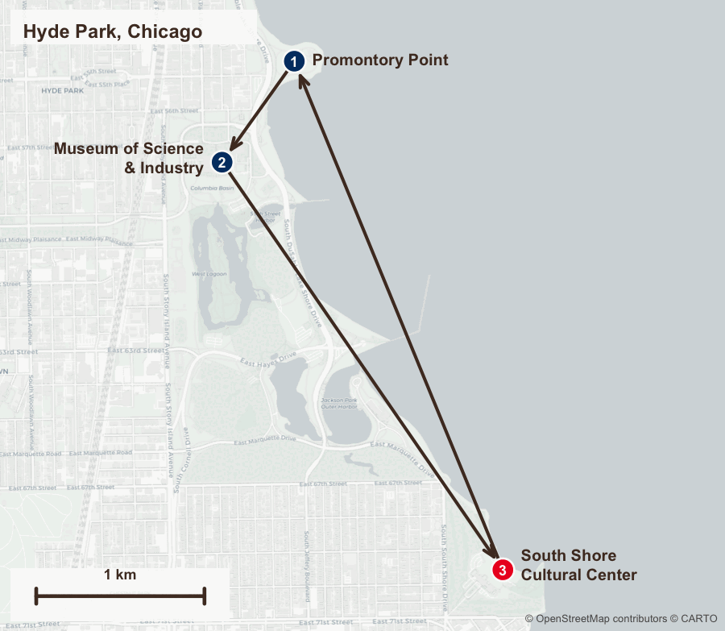

| Tie | Distance | Category |
| --- | --- | --- |
| 1→2 | 0.73 km | 1 |
| 2→3 | 2.92 km | 1 |
| 3→1 | 3.24 km | 2 |

Note that only tie 1→2 falls under a 2 km threshold. Node 3 is the one category-2 node.

## Does it agree with you?

With `thresholds = c(2, 2)`, tie 1→2 is near (0.73 < 2) and the other two are far. That should result in `1.n = 1`, `1.f = 1`, `2.n = 0`, and `2.f = 1`.

```r
summary(g ~ dnf(by = "cat1", thresholds = c(2, 2), base = 4))
```

```
#> dnf.cat1.1.n dnf.cat1.1.f dnf.cat1.2.n
#>            1            1            0
```

```r
summary(g ~ dnf(by = "cat1", thresholds = c(2, 2), base = 1))
```

```
#> dnf.cat1.1.f dnf.cat1.2.n dnf.cat1.2.f
#>            1            0            1
```

- Two calls with different `base` recover different subsets of the four cells.
- Together they sum to **3** edges.

Changing `base` relabels the output. The underlying counts within the 2n cells are fixed.

## Moving the threshold

We drop category 1’s cutoff to 100m and the 0.73km tie should reclassify as far:

```r
summary(g ~ dnf(by = "cat1", thresholds = c(0.1, 2), base = 3))
```

```
#> dnf.cat1.1.n dnf.cat1.1.f dnf.cat1.2.f
#>            0            2            1
```

- `1.n` empties, `1.f` goes from 1 to 2. The category-2 tie is untouched.

The term responds to the threshold exactly where it should, and nowhere else.

# Applying the custom `ergm` term to our n = 1,000 network

## What the term has to overcome

On our n = 1,000 network, a **random** placement of ~900 ties gets classified almost entirely in the far cells:

```r
set.seed(5)
n <- network.size(net)
p <- network.edgecount(net) / (n * (n - 1))
net_rand <- as.network(rgraph(n, tprob = p, mode = "digraph"), directed = TRUE)
net_rand %v% "chicago" <- net %v% "chicago"
net_rand %v% "lat"     <- net %v% "lat"
net_rand %v% "lon"     <- net %v% "lon"

summary(net_rand ~ dnf(by = "chicago", thresholds = c(2, 2)))            # base = 4
```

```
#> dnf.chicago.1.n dnf.chicago.1.f dnf.chicago.2.n
#>               7             468               1
```

```r
summary(net_rand ~ dnf(by = "chicago", thresholds = c(2, 2), base = 3))  # exposes cell 4
```

```
#> dnf.chicago.1.n dnf.chicago.1.f dnf.chicago.2.f
#>               7             468             404
```

Fewer than **1%** of random ties are near. Our empirical targets want **62%**.

Geographic proximity is a prominent feature in this network. The term has to reflect the distribution of near ties.

## Targets for `dnf`

Same recipe as Module 2. Take proportions of total edges, multiply by `edges_target`.

```r
edges_target <- targets$edges_target                        # 711.1

dnf_target <- edges_target * c(.457, .229, .163)            # base cell omitted
```

```
#> 325.0  162.9  115.9
```

| Cell | Share of ties | Target |
| --- | --- | --- |
| `dnf.chicago.1.n` | .457 | 325.0 |
| `dnf.chicago.1.f` | .229 | 162.9 |
| `dnf.chicago.2.n` | .163 | 115.9 |
| `dnf.chicago.2.f` *(base)* | .151 | *107.4* |

The four shares sum to 1, so the base cell is implied and left out.

## Swapping it into the pipeline

One line changes in the mixing block of `exercises/03-sequential.qmd`:

```r
f_mix <- net ~ edges +
  nodemix("sex",      levels2 = -1) +
  nodemix("young",    levels2 = -1) +
  nodemix("race.num", levels2 = -1) +
  dnf(by = "chicago", thresholds = c(2, 2))    # was: nodematch("chicago")

ts_mix <- c(edges_target, sex_target, age_target, race_target,
            dnf_target)

length(summary(f_mix))    # 25 statistics -- was 23 with nodematch("chicago")
length(ts_mix)            # 25 targets -- the two must match
```

- One statistic becomes three, so the target vector grows by two.
- `dnf` is **dyad-independent** (`dependence = FALSE`), so it does not make the mixing block any harder to fit.

## The sibling term `dist()` (another aside)

The package ships a related term we used in [Boodram et al. (2022)](https://doi.org/10.1371/journal.pone.0248850), which bands every tie by distance:

```r
summary(g ~ dist(1:4, breaks = c(0.2, 1.6, 32.2)))   # km cutoffs
```

```
#> dist1 dist2 dist3 dist4
#>     0     1     2     0
```

| Band | Range | In miles |
| --- | --- | --- |
| 1 | < 0.2 km | < 1/8 mile |
| 2 | 0.2 - 1.6 km | 1/8 to 1 mile |
| 3 | 1.6 - 32.2 km | 1 to 20 miles |
| 4 | > 32.2 km | > 20 miles |

- `k` breaks give `k + 1` bands, so the three defaults yield four. Every dyad falls in exactly one band, so `edges + dist(1:4)` is overdetermined. We drop a band to identify the model, same principle as `dnf`’s base cell.

# What did we learn about custom `ergm` terms?

## The general recipe

Nothing here is specific to distance. Four steps add any statistic `ergm` lacks.

Define the cells

→

`InitErgmTerm`

→

C change statistic

→

Verify by hand

1. **Decide what one edge contributes** to each statistic.
2. **On the R side**, validate arguments, name the coefficients, flatten the inputs.
3. **On the C side**, return the change in each statistic for a toggled dyad.
4. **Verify** on a network small enough to check manually.

Start from the `ergm.userterms` template package for the build plumbing. The current API reference is `vignette("Terms-API", package = "ergm")`.

## Recap

- `nodematch("chicago")` carried geography as a label. `dnf` carries it as a **distance**, cross-classified by source.
- The cells partition the edges, so one is dropped as a reference, exactly as with `nodemix`.
- Custom terms are two pieces, an `InitErgmTerm` in R and a change statistic in C.
- The term is dyad-independent, so it slots into the Module 3 pipeline for the cost of two extra targets.
- Custom terms should be **verified on test networks**.

When `ergm` has no term for your data, write one.